# ASV vs OTU

## Avantages des ASV sur les OTU

[Les ASV devraient remplacer les OTU](https://www.nature.com/articles/ismej2017119)  
[DADA2, logiciel d’analyse de séquences](https://www.nature.com/articles/nmeth.3869)

Les ASV (Amplicon sequence variant), sont des variants exacts du gène 16S séquencé. Ils discriminent des séquences ayant ne serait ce qu’un nucléotide de différence et permettent ainsi de grouper les séquences similaires.

Les OTU sont des groupements de séquences présentant moins de 3% de dissimilaritées entre eux et étant proche d’une séquence de référence issue d’une base de données (ici SILVA align). L’intérêt initial des OTU était de réduire l’impact des erreurs liées au séquençage en groupant les séquences semblables avec une marge d’erreur de 3%. Ils présentaient aussi l’intérêt d’obtenir des groupes important s’apparentant à des espèces afin d’y appliquer les théories d’écologie des populations précédemment appliquée à d’autres milieux.

L’amélioration des techniques d’analyse permet d’identifier les erreurs de séquençage, et ainsi de permettre l’utilisation fiable des ASV. Pour cela un modèle d’erreur est appliqué aux séquences afin de détecter et substituer les nucléotides erronés.

**Avantages des ASV**  
- Présente une plus grande résolution.  
- Plus grande significativité biologique et identification de mécanismes écologiques en isolant uniquement les variant naturels exacts.  
- **Reproductibilité** possible comparaison des ASV entres plusieurs études contrairement aux OTU qui dont les groupements ne sont pas reproductibles.  
- Le calcul de la distance phylogénétique est plus précis, car basé sur la séquence exacte.

Contrairement aux ASV les OTU sont groupés par comparaison à une base de données d’alignement. Ce système pose problème dans le cas de milieux peu étudiés comme les eaux souterraines ou les bases de données ne sont pas complètes. Les ASV permettent donc de **mieux représenter la variation dans les communautés.**

**Remplacer les OTU par les ASV rend les analyses d’écologie microbienne par séquençage haut débit plus précise, réutilisable, reproductible et plus compréhensive!**

## Différence entre ASV et OTU dans mes données

### Comparer la diversité de chacun des sites en utilisant l’indice de shannon

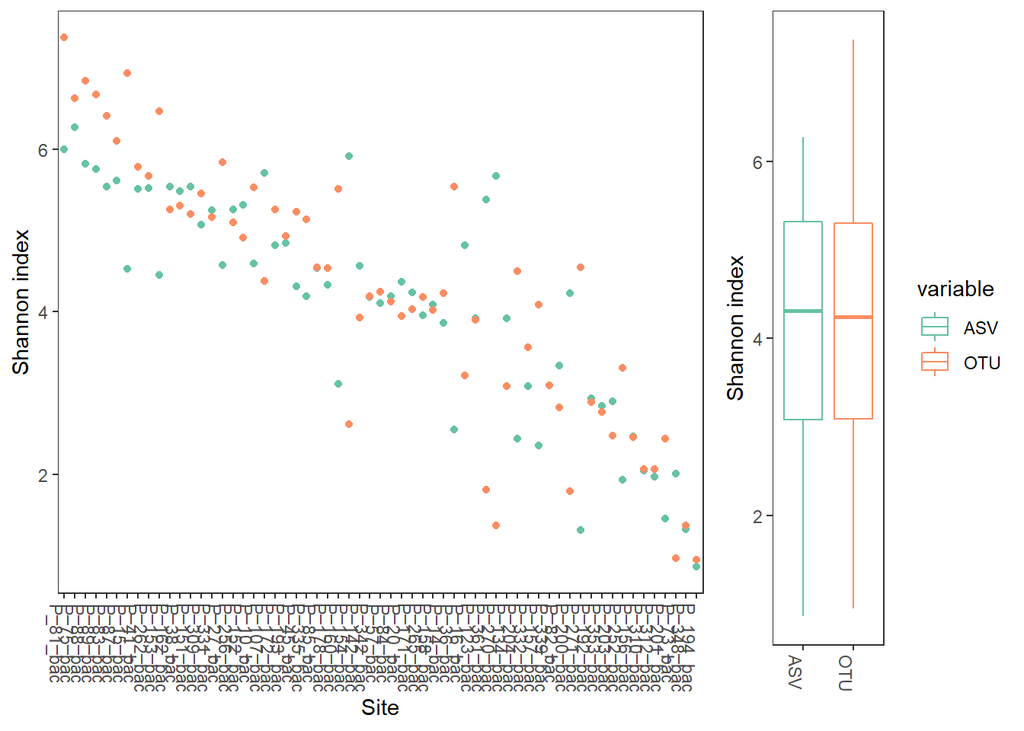

On observe une tendance similaire entre ASV et OTU sur l’ensemble des sites en terme de diversitée.

La différence dans la diversité, en plus d’étre explquée par la différence de traitement entre ASV et OTU, peut étre du à la méthode de classification. Les ASV ont été classifié a l’aide de [iDTAXA](https://microbiomejournal.biomedcentral.com/articles/10.1186/s40168-018-0521-5)

### Comparer l’abondance d’amplicon dans chacun des sites

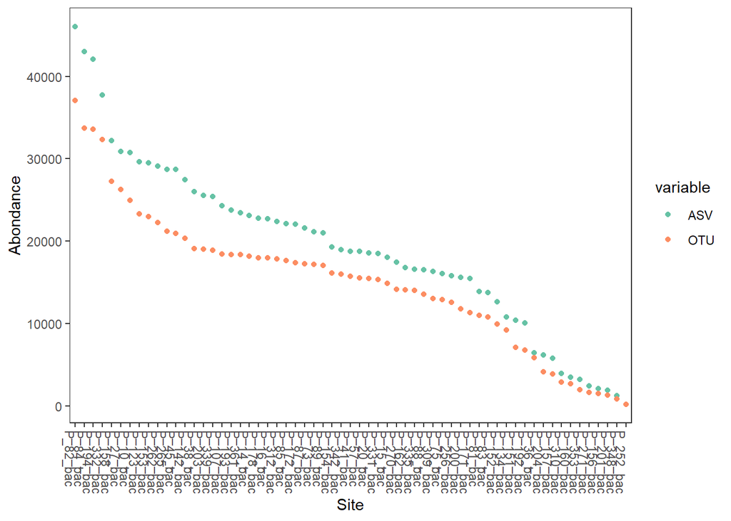

L’abondance d’ASV dans chacun des sites sembles plutot proportionel a l’abondance d’OTU!

### Dispersion des sites basé sur la diversitée.

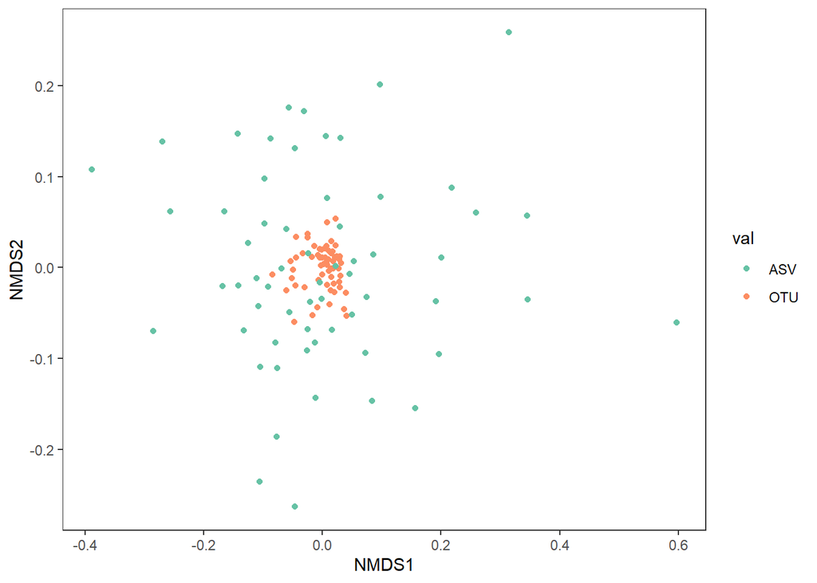

Différence entre chaque site en terme de diversité, basé sur le calcule de l’indice de dissimilarité de Bray-Curtis, a partir de l’abondance relative d’OTU ou d’ASV.

### Familles les plus abondantes

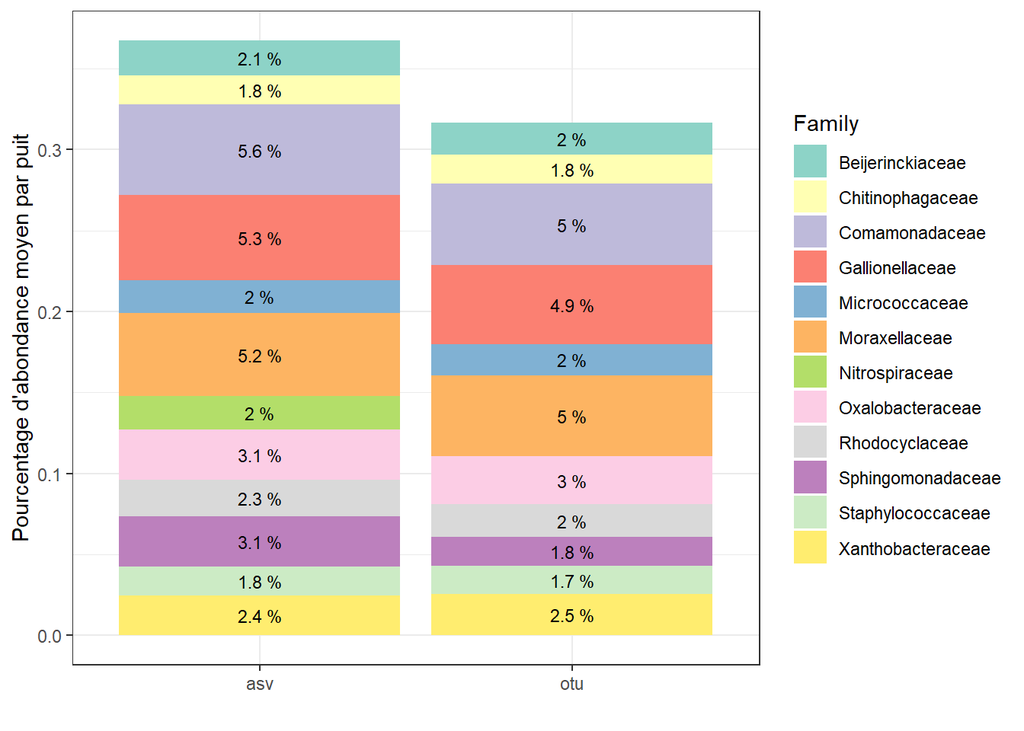

On observe que parmi les 12 familles bactériennes les plus abondantes entre ASV et OTU seul une différe. *Nitrospiraceae* est plus abondant chez les ASV.